# HendricksonSwen_A3

Swen Hendrickson

10/13/2021

# Introduction:

For my analysis of vulnerability to heat waves in the Bay Area, I chose to focus on three characteristics in defining my ‘at-risk’ population: 1: age, 2: language, and 3: cost of electricity. Specifically, from the available variables on the 2019 ACS, I used 1: AGEP: an integer representing someone’s age in years. 2: HHL: for primary House-hold language spoken at home, and 3: ELEP: for monthly electricity cost. In defining my vulnerable population, I filtered each variable as follows: 1. Age to only include people at or above the age of 65, 2. Household language to include only houses where English is NOT the primary language, and 3. Electricity cost for any bill coming in over $100 per month (after running hist() on each variable from the initial nation-wide pums data, $50-100 was the highest frequency value [mode] in the histogram, so >$100 seemed a natural way to define ‘expensive electricity’).

# Quick look at my chosen variables:

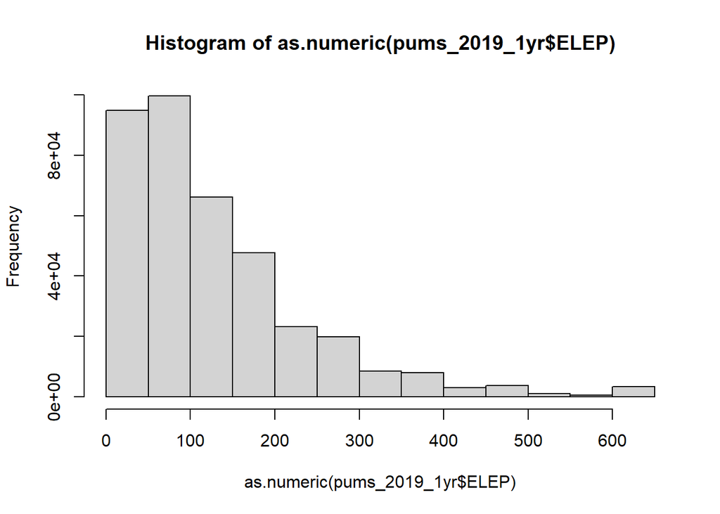

- Takeaway: most people have affordable electricity price, but some do have very expensive. Above 100 is a logical cut off point.

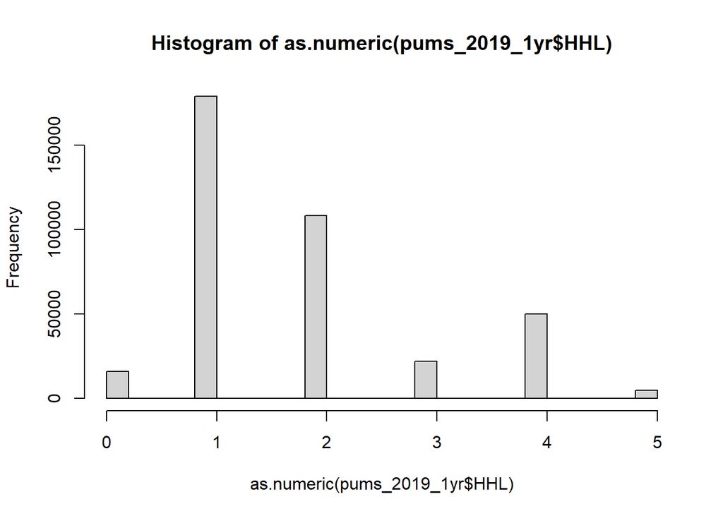

- Takeaway: English predominant language, but many households with other languages as primary household language.

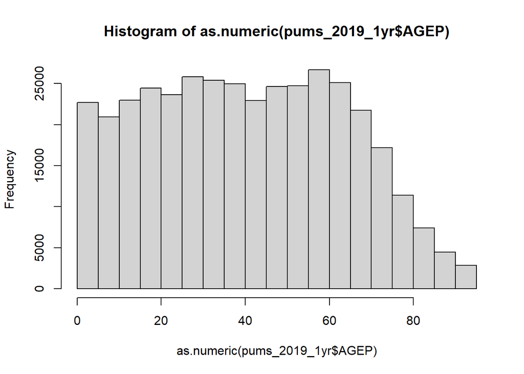

- Takeaway: Over 65 population smaller and tailing off, but still substantive.

# Key Assumptions:

## Age:

[interactive chart not shown]

```
## [1] 442.0312
```

# Takeaways / Usefulness:

I feel pretty confident in my assumptions that older age increases risk of health effects, and that having a primary language other than English makes resources in the Bay Area harder to access to some degree. The Electricity Cost variable feels that it makes the biggest assumption, in terms of requiring multiple dots to be connected in order to make sense. Given more time, I would explore the 518 available variables more for factors that more obviously or directly contribute to vulnerability in heat waves. In my first attempt, I used the REFR variable indicating the number of refrigerators in each house, believing that cold drinks (and perhaps ice packs) are an important source of relief during heat waves, especially in households that do not have AC. The population without a refrigerator was far too small to yield useful results. Some other factors I might think to consider include infants (also more susceptible to health effects), whether people of certain racial groups have higher rates of heat-related health issues, and perhaps some variable that can help determine the localized heat intensity for certain houses or areas - for example if there are trees and parks nearby providing shade, or whether a house is in a denser neighborhood surrounded by other buildings and roads which radiate more heat.

To put my analysis in perspective, the total number of individuals meeting all three criteria (1: older than 65, 2: English NOT primary household language, and 3: monthly electricity costs greater than $100) was only 442 people. This analysis offered a useful exercise in data retrieval, coding, and analytical parameter-setting. However, given another pass, I would seek out variables that yielded a larger at-risk population, and perhaps one for whom a large-scale solution could be presented.